# Risk Factor Analysis

## Outcome Variable

**Outcome Variable:** wasted

## Predictor Variables

**Intervention Variable:** earlybf

**Adjustment Set:**

unadjusted

## Stratifying Variables

The analysis was stratified on these variable(s):

- agecat
- studyid
- country

## Data Summary

| agecat | studyid | country | earlybf | wasted | n_cell | n |
| --- | --- | --- | --- | --- | --- | --- |
| Birth | ki0047075b-MAL-ED | BANGLADESH | 0 | 0 | 70 | 240 |
| Birth | ki0047075b-MAL-ED | BANGLADESH | 0 | 1 | 18 | 240 |
| Birth | ki0047075b-MAL-ED | BANGLADESH | 1 | 0 | 130 | 240 |
| Birth | ki0047075b-MAL-ED | BANGLADESH | 1 | 1 | 22 | 240 |
| Birth | ki0047075b-MAL-ED | BRAZIL | 0 | 0 | 100 | 183 |
| Birth | ki0047075b-MAL-ED | BRAZIL | 0 | 1 | 4 | 183 |
| Birth | ki0047075b-MAL-ED | BRAZIL | 1 | 0 | 77 | 183 |
| Birth | ki0047075b-MAL-ED | BRAZIL | 1 | 1 | 2 | 183 |
| Birth | ki0047075b-MAL-ED | INDIA | 0 | 0 | 65 | 202 |
| Birth | ki0047075b-MAL-ED | INDIA | 0 | 1 | 14 | 202 |
| Birth | ki0047075b-MAL-ED | INDIA | 1 | 0 | 104 | 202 |
| Birth | ki0047075b-MAL-ED | INDIA | 1 | 1 | 19 | 202 |
| Birth | ki0047075b-MAL-ED | NEPAL | 0 | 0 | 83 | 168 |
| Birth | ki0047075b-MAL-ED | NEPAL | 0 | 1 | 8 | 168 |
| Birth | ki0047075b-MAL-ED | NEPAL | 1 | 0 | 65 | 168 |
| Birth | ki0047075b-MAL-ED | NEPAL | 1 | 1 | 12 | 168 |
| Birth | ki0047075b-MAL-ED | PERU | 0 | 0 | 66 | 279 |
| Birth | ki0047075b-MAL-ED | PERU | 0 | 1 | 2 | 279 |
| Birth | ki0047075b-MAL-ED | PERU | 1 | 0 | 207 | 279 |
| Birth | ki0047075b-MAL-ED | PERU | 1 | 1 | 4 | 279 |
| Birth | ki0047075b-MAL-ED | SOUTH AFRICA | 0 | 0 | 81 | 245 |
| Birth | ki0047075b-MAL-ED | SOUTH AFRICA | 0 | 1 | 10 | 245 |
| Birth | ki0047075b-MAL-ED | SOUTH AFRICA | 1 | 0 | 148 | 245 |
| Birth | ki0047075b-MAL-ED | SOUTH AFRICA | 1 | 1 | 6 | 245 |
| Birth | ki0047075b-MAL-ED | TANZANIA, UNITED REPUBLIC OF | 0 | 0 | 10 | 118 |
| Birth | ki0047075b-MAL-ED | TANZANIA, UNITED REPUBLIC OF | 0 | 1 | 0 | 118 |
| Birth | ki0047075b-MAL-ED | TANZANIA, UNITED REPUBLIC OF | 1 | 0 | 106 | 118 |
| Birth | ki0047075b-MAL-ED | TANZANIA, UNITED REPUBLIC OF | 1 | 1 | 2 | 118 |
| Birth | ki1000109-EE | PAKISTAN | 0 | 0 | 0 | 1 |
| Birth | ki1000109-EE | PAKISTAN | 0 | 1 | 0 | 1 |

[output cut: 126 more lines]

The following strata were considered:

- agecat: 24 months, studyid: ki0047075b-MAL-ED, country: BANGLADESH
- agecat: 24 months, studyid: ki0047075b-MAL-ED, country: BRAZIL
- agecat: 24 months, studyid: ki0047075b-MAL-ED, country: INDIA
- agecat: 24 months, studyid: ki0047075b-MAL-ED, country: NEPAL
- agecat: 24 months, studyid: ki0047075b-MAL-ED, country: PERU
- agecat: 24 months, studyid: ki0047075b-MAL-ED, country: SOUTH AFRICA
- agecat: 24 months, studyid: ki0047075b-MAL-ED, country: TANZANIA, UNITED REPUBLIC OF
- agecat: 24 months, studyid: ki1017093c-NIH-Crypto, country: BANGLADESH
- agecat: 24 months, studyid: ki1113344-GMS-Nepal, country: NEPAL
- agecat: 24 months, studyid: ki1126311-ZVITAMBO, country: ZIMBABWE
- agecat: 24 months, studyid: kiGH5241-JiVitA-3, country: BANGLADESH
- agecat: 24 months, studyid: kiGH5241-JiVitA-4, country: BANGLADESH
- agecat: 6 months, studyid: ki0047075b-MAL-ED, country: BANGLADESH
- agecat: 6 months, studyid: ki0047075b-MAL-ED, country: BRAZIL
- agecat: 6 months, studyid: ki0047075b-MAL-ED, country: INDIA
- agecat: 6 months, studyid: ki0047075b-MAL-ED, country: NEPAL
- agecat: 6 months, studyid: ki0047075b-MAL-ED, country: PERU
- agecat: 6 months, studyid: ki0047075b-MAL-ED, country: SOUTH AFRICA
- agecat: 6 months, studyid: ki0047075b-MAL-ED, country: TANZANIA, UNITED REPUBLIC OF
- agecat: 6 months, studyid: ki1000109-EE, country: PAKISTAN
- agecat: 6 months, studyid: ki1000304b-SAS-CompFeed, country: INDIA
- agecat: 6 months, studyid: ki1017093c-NIH-Crypto, country: BANGLADESH
- agecat: 6 months, studyid: ki1113344-GMS-Nepal, country: NEPAL
- agecat: 6 months, studyid: ki1126311-ZVITAMBO, country: ZIMBABWE
- agecat: 6 months, studyid: kiGH5241-JiVitA-3, country: BANGLADESH
- agecat: 6 months, studyid: kiGH5241-JiVitA-4, country: BANGLADESH
- agecat: Birth, studyid: ki0047075b-MAL-ED, country: BANGLADESH
- agecat: Birth, studyid: ki0047075b-MAL-ED, country: BRAZIL
- agecat: Birth, studyid: ki0047075b-MAL-ED, country: INDIA
- agecat: Birth, studyid: ki0047075b-MAL-ED, country: NEPAL
- agecat: Birth, studyid: ki0047075b-MAL-ED, country: PERU
- agecat: Birth, studyid: ki0047075b-MAL-ED, country: SOUTH AFRICA
- agecat: Birth, studyid: ki0047075b-MAL-ED, country: TANZANIA, UNITED REPUBLIC OF
- agecat: Birth, studyid: ki1000109-EE, country: PAKISTAN
- agecat: Birth, studyid: ki1000304b-SAS-CompFeed, country: INDIA
- agecat: Birth, studyid: ki1017093c-NIH-Crypto, country: BANGLADESH
- agecat: Birth, studyid: ki1126311-ZVITAMBO, country: ZIMBABWE
- agecat: Birth, studyid: kiGH5241-JiVitA-3, country: BANGLADESH
- agecat: Birth, studyid: kiGH5241-JiVitA-4, country: BANGLADESH

### Dropped Strata

Some strata were dropped due to rare outcomes:

- agecat: Birth, studyid: ki0047075b-MAL-ED, country: BRAZIL
- agecat: Birth, studyid: ki0047075b-MAL-ED, country: PERU
- agecat: Birth, studyid: ki0047075b-MAL-ED, country: TANZANIA, UNITED REPUBLIC OF
- agecat: Birth, studyid: ki1000109-EE, country: PAKISTAN
- agecat: Birth, studyid: ki1000304b-SAS-CompFeed, country: INDIA
- agecat: Birth, studyid: ki1017093c-NIH-Crypto, country: BANGLADESH
- agecat: 6 months, studyid: ki0047075b-MAL-ED, country: BANGLADESH
- agecat: 6 months, studyid: ki0047075b-MAL-ED, country: BRAZIL
- agecat: 6 months, studyid: ki0047075b-MAL-ED, country: NEPAL
- agecat: 6 months, studyid: ki0047075b-MAL-ED, country: PERU
- agecat: 6 months, studyid: ki0047075b-MAL-ED, country: SOUTH AFRICA
- agecat: 6 months, studyid: ki0047075b-MAL-ED, country: TANZANIA, UNITED REPUBLIC OF
- agecat: 6 months, studyid: ki1017093c-NIH-Crypto, country: BANGLADESH
- agecat: 24 months, studyid: ki0047075b-MAL-ED, country: BRAZIL
- agecat: 24 months, studyid: ki0047075b-MAL-ED, country: NEPAL
- agecat: 24 months, studyid: ki0047075b-MAL-ED, country: PERU
- agecat: 24 months, studyid: ki0047075b-MAL-ED, country: SOUTH AFRICA
- agecat: 24 months, studyid: ki0047075b-MAL-ED, country: TANZANIA, UNITED REPUBLIC OF
- agecat: 24 months, studyid: ki1017093c-NIH-Crypto, country: BANGLADESH
- agecat: 24 months, studyid: kiGH5241-JiVitA-3, country: BANGLADESH

## Methods Detail

We’re interested in the causal parameters $E[Y_a]$ for all values of $a \in \mathcal{A}$. These parameters represent the mean outcome if, possibly contrary to fact, we intervened to set all units to have $A=a$. Under the randomization and positivity assumptions, these are identified by the statistical parameters $\psi_a=E_W[E_{Y|A,W}(Y|A=a,W)]$. In addition, we’re interested in the mean of $Y$, $E[Y]$ under no intervention (the observed mean). We will estimate these parameters by using SuperLearner to fit the relevant likelihood factors – $E_{Y|A,W}(Y|A=a,W)$ and $p(A=a|W)$, and then updating our likelihood fit using a joint TMLE.

For unadjusted analyses ($W=\{\}$), initial likelihoods were estimated using Lrnr_glm to estimate the simple $E(Y|A)$ and Lrnr_mean to estimate $p(A)$. For adjusted analyses, a small library containing Lrnr_glmnet, Lrnr_xgboost, and Lrnr_mean was used.

Having estimated these parameters, we will then use the delta method to estimate relative risks and attributable risks relative to a prespecified baseline level of $A$.

# Results Detail

## Results Plots

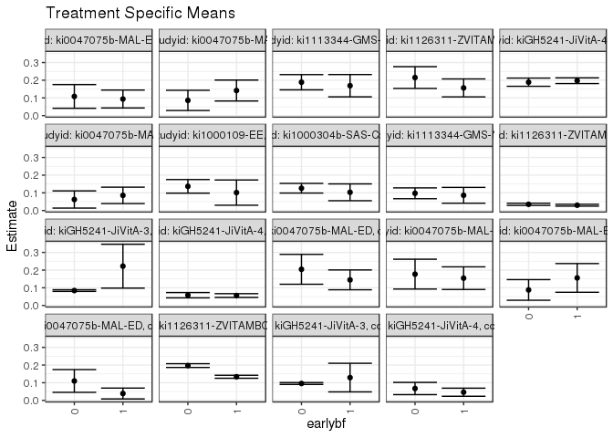

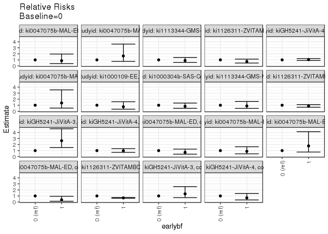

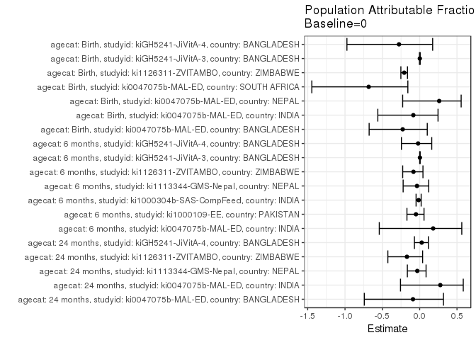

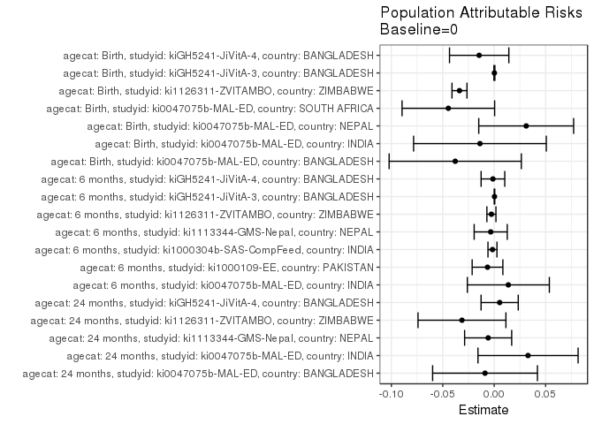

## Results Table

### Parameter: TSM

| agecat | studyid | country | intervention_level | baseline_level | estimate | ci_lower | ci_upper |
| --- | --- | --- | --- | --- | --- | --- | --- |
| Birth | ki0047075b-MAL-ED | BANGLADESH | 0 | NA | 0.2045455 | 0.1200923 | 0.2889986 |
| Birth | ki0047075b-MAL-ED | BANGLADESH | 1 | NA | 0.1447368 | 0.0886873 | 0.2007864 |
| Birth | ki0047075b-MAL-ED | INDIA | 0 | NA | 0.1772152 | 0.0928029 | 0.2616275 |
| Birth | ki0047075b-MAL-ED | INDIA | 1 | NA | 0.1544715 | 0.0904448 | 0.2184983 |
| Birth | ki0047075b-MAL-ED | NEPAL | 0 | NA | 0.0879121 | 0.0295587 | 0.1462655 |
| Birth | ki0047075b-MAL-ED | NEPAL | 1 | NA | 0.1558442 | 0.0745881 | 0.2371002 |
| Birth | ki0047075b-MAL-ED | SOUTH AFRICA | 0 | NA | 0.1098901 | 0.0455004 | 0.1742798 |
| Birth | ki0047075b-MAL-ED | SOUTH AFRICA | 1 | NA | 0.0389610 | 0.0083371 | 0.0695850 |
| Birth | ki1126311-ZVITAMBO | ZIMBABWE | 0 | NA | 0.1969471 | 0.1863119 | 0.2075823 |
| Birth | ki1126311-ZVITAMBO | ZIMBABWE | 1 | NA | 0.1336916 | 0.1251795 | 0.1422037 |
| Birth | kiGH5241-JiVitA-3 | BANGLADESH | 0 | NA | 0.0957248 | 0.0904923 | 0.1009574 |
| Birth | kiGH5241-JiVitA-3 | BANGLADESH | 1 | NA | 0.1290323 | 0.0481362 | 0.2099283 |
| Birth | kiGH5241-JiVitA-4 | BANGLADESH | 0 | NA | 0.0673077 | 0.0327433 | 0.1018720 |
| Birth | kiGH5241-JiVitA-4 | BANGLADESH | 1 | NA | 0.0463158 | 0.0234675 | 0.0691641 |
| 6 months | ki0047075b-MAL-ED | INDIA | 0 | NA | 0.0625000 | 0.0139756 | 0.1110244 |
| 6 months | ki0047075b-MAL-ED | INDIA | 1 | NA | 0.0857143 | 0.0392442 | 0.1321844 |
| 6 months | ki1000109-EE | PAKISTAN | 0 | NA | 0.1368078 | 0.0983162 | 0.1752995 |
| 6 months | ki1000109-EE | PAKISTAN | 1 | NA | 0.1014493 | 0.0301151 | 0.1727834 |
| 6 months | ki1000304b-SAS-CompFeed | INDIA | 0 | NA | 0.1261116 | 0.0987820 | 0.1534411 |
| 6 months | ki1000304b-SAS-CompFeed | INDIA | 1 | NA | 0.1030928 | 0.0556218 | 0.1505638 |
| 6 months | ki1113344-GMS-Nepal | NEPAL | 0 | NA | 0.0974930 | 0.0667788 | 0.1282072 |
| 6 months | ki1113344-GMS-Nepal | NEPAL | 1 | NA | 0.0860927 | 0.0413090 | 0.1308764 |
| 6 months | ki1126311-ZVITAMBO | ZIMBABWE | 0 | NA | 0.0351240 | 0.0289247 | 0.0413233 |
| 6 months | ki1126311-ZVITAMBO | ZIMBABWE | 1 | NA | 0.0301190 | 0.0247892 | 0.0354487 |
| 6 months | kiGH5241-JiVitA-3 | BANGLADESH | 0 | NA | 0.0843683 | 0.0795754 | 0.0891612 |
| 6 months | kiGH5241-JiVitA-3 | BANGLADESH | 1 | NA | 0.2222222 | 0.0982018 | 0.3462426 |
| 6 months | kiGH5241-JiVitA-4 | BANGLADESH | 0 | NA | 0.0581128 | 0.0431483 | 0.0730773 |
| 6 months | kiGH5241-JiVitA-4 | BANGLADESH | 1 | NA | 0.0562197 | 0.0456225 | 0.0668169 |
| 24 months | ki0047075b-MAL-ED | BANGLADESH | 0 | NA | 0.1084337 | 0.0413836 | 0.1754839 |
| 24 months | ki0047075b-MAL-ED | BANGLADESH | 1 | NA | 0.0937500 | 0.0431344 | 0.1443656 |
| 24 months | ki0047075b-MAL-ED | INDIA | 0 | NA | 0.0860215 | 0.0289083 | 0.1431348 |
| 24 months | ki0047075b-MAL-ED | INDIA | 1 | NA | 0.1417910 | 0.0825974 | 0.2009847 |
| 24 months | ki1113344-GMS-Nepal | NEPAL | 0 | NA | 0.1886792 | 0.1456294 | 0.2317291 |
| 24 months | ki1113344-GMS-Nepal | NEPAL | 1 | NA | 0.1691176 | 0.1060478 | 0.2321875 |
| 24 months | ki1126311-ZVITAMBO | ZIMBABWE | 0 | NA | 0.2151163 | 0.1536254 | 0.2766072 |
| 24 months | ki1126311-ZVITAMBO | ZIMBABWE | 1 | NA | 0.1565657 | 0.1058809 | 0.2072504 |
| 24 months | kiGH5241-JiVitA-4 | BANGLADESH | 0 | NA | 0.1889671 | 0.1658292 | 0.2121051 |
| 24 months | kiGH5241-JiVitA-4 | BANGLADESH | 1 | NA | 0.1972946 | 0.1812292 | 0.2133601 |

### Parameter: E(Y)

| agecat | studyid | country | intervention_level | baseline_level | estimate | ci_lower | ci_upper |
| --- | --- | --- | --- | --- | --- | --- | --- |
| Birth | ki0047075b-MAL-ED | BANGLADESH | NA | NA | 0.1666667 | 0.1194187 | 0.2139146 |
| Birth | ki0047075b-MAL-ED | INDIA | NA | NA | 0.1633663 | 0.1122571 | 0.2144755 |
| Birth | ki0047075b-MAL-ED | NEPAL | NA | NA | 0.1190476 | 0.0699312 | 0.1681640 |
| Birth | ki0047075b-MAL-ED | SOUTH AFRICA | NA | NA | 0.0653061 | 0.0343059 | 0.0963063 |
| Birth | ki1126311-ZVITAMBO | ZIMBABWE | NA | NA | 0.1632068 | 0.1564561 | 0.1699575 |
| Birth | kiGH5241-JiVitA-3 | BANGLADESH | NA | NA | 0.0959228 | 0.0907196 | 0.1011260 |
| Birth | kiGH5241-JiVitA-4 | BANGLADESH | NA | NA | 0.0527086 | 0.0336587 | 0.0717585 |
| 6 months | ki0047075b-MAL-ED | INDIA | NA | NA | 0.0762712 | 0.0423347 | 0.1102077 |
| 6 months | ki1000109-EE | PAKISTAN | NA | NA | 0.1303191 | 0.0962457 | 0.1643926 |
| 6 months | ki1000304b-SAS-CompFeed | INDIA | NA | NA | 0.1244378 | 0.0992652 | 0.1496104 |
| 6 months | ki1113344-GMS-Nepal | NEPAL | NA | NA | 0.0941176 | 0.0687511 | 0.1194842 |
| 6 months | ki1126311-ZVITAMBO | ZIMBABWE | NA | NA | 0.0324295 | 0.0283765 | 0.0364824 |
| 6 months | kiGH5241-JiVitA-3 | BANGLADESH | NA | NA | 0.0846640 | 0.0798626 | 0.0894653 |
| 6 months | kiGH5241-JiVitA-4 | BANGLADESH | NA | NA | 0.0569005 | 0.0480577 | 0.0657432 |
| 24 months | ki0047075b-MAL-ED | BANGLADESH | NA | NA | 0.0995261 | 0.0590366 | 0.1400156 |
| 24 months | ki0047075b-MAL-ED | INDIA | NA | NA | 0.1189427 | 0.0767376 | 0.1611478 |
| 24 months | ki1113344-GMS-Nepal | NEPAL | NA | NA | 0.1828194 | 0.1472260 | 0.2184128 |
| 24 months | ki1126311-ZVITAMBO | ZIMBABWE | NA | NA | 0.1837838 | 0.1442661 | 0.2233014 |
| 24 months | kiGH5241-JiVitA-4 | BANGLADESH | NA | NA | 0.1942978 | 0.1810880 | 0.2075076 |

### Parameter: RR

| agecat | studyid | country | intervention_level | baseline_level | estimate | ci_lower | ci_upper |
| --- | --- | --- | --- | --- | --- | --- | --- |
| Birth | ki0047075b-MAL-ED | BANGLADESH | 0 | 0 | 1.0000000 | 1.0000000 | 1.0000000 |
| Birth | ki0047075b-MAL-ED | BANGLADESH | 1 | 0 | 0.7076023 | 0.4017428 | 1.2463226 |
| Birth | ki0047075b-MAL-ED | INDIA | 0 | 0 | 1.0000000 | 1.0000000 | 1.0000000 |
| Birth | ki0047075b-MAL-ED | INDIA | 1 | 0 | 0.8716609 | 0.4635818 | 1.6389615 |
| Birth | ki0047075b-MAL-ED | NEPAL | 0 | 0 | 1.0000000 | 1.0000000 | 1.0000000 |
| Birth | ki0047075b-MAL-ED | NEPAL | 1 | 0 | 1.7727273 | 0.7622022 | 4.1230032 |
| Birth | ki0047075b-MAL-ED | SOUTH AFRICA | 0 | 0 | 1.0000000 | 1.0000000 | 1.0000000 |
| Birth | ki0047075b-MAL-ED | SOUTH AFRICA | 1 | 0 | 0.3545455 | 0.1330137 | 0.9450341 |
| Birth | ki1126311-ZVITAMBO | ZIMBABWE | 0 | 0 | 1.0000000 | 1.0000000 | 1.0000000 |
| Birth | ki1126311-ZVITAMBO | ZIMBABWE | 1 | 0 | 0.6788196 | 0.6244491 | 0.7379241 |
| Birth | kiGH5241-JiVitA-3 | BANGLADESH | 0 | 0 | 1.0000000 | 1.0000000 | 1.0000000 |
| Birth | kiGH5241-JiVitA-3 | BANGLADESH | 1 | 0 | 1.3479495 | 0.7165299 | 2.5357880 |
| Birth | kiGH5241-JiVitA-4 | BANGLADESH | 0 | 0 | 1.0000000 | 1.0000000 | 1.0000000 |
| Birth | kiGH5241-JiVitA-4 | BANGLADESH | 1 | 0 | 0.6881203 | 0.3375605 | 1.4027397 |
| 6 months | ki0047075b-MAL-ED | INDIA | 0 | 0 | 1.0000000 | 1.0000000 | 1.0000000 |
| 6 months | ki0047075b-MAL-ED | INDIA | 1 | 0 | 1.3714286 | 0.5320090 | 3.5353092 |
| 6 months | ki1000109-EE | PAKISTAN | 0 | 0 | 1.0000000 | 1.0000000 | 1.0000000 |
| 6 months | ki1000109-EE | PAKISTAN | 1 | 0 | 0.7415459 | 0.3477156 | 1.5814371 |
| 6 months | ki1000304b-SAS-CompFeed | INDIA | 0 | 0 | 1.0000000 | 1.0000000 | 1.0000000 |
| 6 months | ki1000304b-SAS-CompFeed | INDIA | 1 | 0 | 0.8174729 | 0.4938733 | 1.3531042 |
| 6 months | ki1113344-GMS-Nepal | NEPAL | 0 | 0 | 1.0000000 | 1.0000000 | 1.0000000 |
| 6 months | ki1113344-GMS-Nepal | NEPAL | 1 | 0 | 0.8830653 | 0.4807063 | 1.6222052 |
| 6 months | ki1126311-ZVITAMBO | ZIMBABWE | 0 | 0 | 1.0000000 | 1.0000000 | 1.0000000 |
| 6 months | ki1126311-ZVITAMBO | ZIMBABWE | 1 | 0 | 0.8575044 | 0.6678722 | 1.1009798 |
| 6 months | kiGH5241-JiVitA-3 | BANGLADESH | 0 | 0 | 1.0000000 | 1.0000000 | 1.0000000 |
| 6 months | kiGH5241-JiVitA-3 | BANGLADESH | 1 | 0 | 2.6339545 | 1.5065764 | 4.6049552 |
| 6 months | kiGH5241-JiVitA-4 | BANGLADESH | 0 | 0 | 1.0000000 | 1.0000000 | 1.0000000 |
| 6 months | kiGH5241-JiVitA-4 | BANGLADESH | 1 | 0 | 0.9674243 | 0.7078186 | 1.3222452 |
| 24 months | ki0047075b-MAL-ED | BANGLADESH | 0 | 0 | 1.0000000 | 1.0000000 | 1.0000000 |
| 24 months | ki0047075b-MAL-ED | BANGLADESH | 1 | 0 | 0.8645833 | 0.3804535 | 1.9647716 |
| 24 months | ki0047075b-MAL-ED | INDIA | 0 | 0 | 1.0000000 | 1.0000000 | 1.0000000 |
| 24 months | ki0047075b-MAL-ED | INDIA | 1 | 0 | 1.6483209 | 0.7523706 | 3.6112015 |
| 24 months | ki1113344-GMS-Nepal | NEPAL | 0 | 0 | 1.0000000 | 1.0000000 | 1.0000000 |
| 24 months | ki1113344-GMS-Nepal | NEPAL | 1 | 0 | 0.8963235 | 0.5788867 | 1.3878293 |
| 24 months | ki1126311-ZVITAMBO | ZIMBABWE | 0 | 0 | 1.0000000 | 1.0000000 | 1.0000000 |
| 24 months | ki1126311-ZVITAMBO | ZIMBABWE | 1 | 0 | 0.7278187 | 0.4725691 | 1.1209367 |
| 24 months | kiGH5241-JiVitA-4 | BANGLADESH | 0 | 0 | 1.0000000 | 1.0000000 | 1.0000000 |
| 24 months | kiGH5241-JiVitA-4 | BANGLADESH | 1 | 0 | 1.0440684 | 0.9010614 | 1.2097720 |

### Parameter: PAR

| agecat | studyid | country | intervention_level | baseline_level | estimate | ci_lower | ci_upper |
| --- | --- | --- | --- | --- | --- | --- | --- |
| Birth | ki0047075b-MAL-ED | BANGLADESH | 0 | NA | -0.0378788 | -0.1021775 | 0.0264199 |
| Birth | ki0047075b-MAL-ED | INDIA | 0 | NA | -0.0138489 | -0.0783797 | 0.0506820 |
| Birth | ki0047075b-MAL-ED | NEPAL | 0 | NA | 0.0311355 | -0.0150019 | 0.0772729 |
| Birth | ki0047075b-MAL-ED | SOUTH AFRICA | 0 | NA | -0.0445840 | -0.0896077 | 0.0004398 |
| Birth | ki1126311-ZVITAMBO | ZIMBABWE | 0 | NA | -0.0337403 | -0.0410292 | -0.0264515 |
| Birth | kiGH5241-JiVitA-3 | BANGLADESH | 0 | NA | 0.0001980 | -0.0002935 | 0.0006894 |
| Birth | kiGH5241-JiVitA-4 | BANGLADESH | 0 | NA | -0.0145991 | -0.0434476 | 0.0142495 |
| 6 months | ki0047075b-MAL-ED | INDIA | 0 | NA | 0.0137712 | -0.0261121 | 0.0536545 |
| 6 months | ki1000109-EE | PAKISTAN | 0 | NA | -0.0064887 | -0.0214278 | 0.0084504 |
| 6 months | ki1000304b-SAS-CompFeed | INDIA | 0 | NA | -0.0016738 | -0.0060454 | 0.0026978 |
| 6 months | ki1113344-GMS-Nepal | NEPAL | 0 | NA | -0.0033754 | -0.0194600 | 0.0127093 |
| 6 months | ki1126311-ZVITAMBO | ZIMBABWE | 0 | NA | -0.0026945 | -0.0070961 | 0.0017072 |
| 6 months | kiGH5241-JiVitA-3 | BANGLADESH | 0 | NA | 0.0002957 | 0.0000189 | 0.0005724 |
| 6 months | kiGH5241-JiVitA-4 | BANGLADESH | 0 | NA | -0.0012123 | -0.0127093 | 0.0102847 |
| 24 months | ki0047075b-MAL-ED | BANGLADESH | 0 | NA | -0.0089077 | -0.0598802 | 0.0420649 |
| 24 months | ki0047075b-MAL-ED | INDIA | 0 | NA | 0.0329212 | -0.0157658 | 0.0816083 |
| 24 months | ki1113344-GMS-Nepal | NEPAL | 0 | NA | -0.0058599 | -0.0287496 | 0.0170299 |
| 24 months | ki1126311-ZVITAMBO | ZIMBABWE | 0 | NA | -0.0313325 | -0.0740800 | 0.0114150 |
| 24 months | kiGH5241-JiVitA-4 | BANGLADESH | 0 | NA | 0.0053306 | -0.0127386 | 0.0233999 |

### Parameter: PAF

| agecat | studyid | country | intervention_level | baseline_level | estimate | ci_lower | ci_upper |
| --- | --- | --- | --- | --- | --- | --- | --- |
| Birth | ki0047075b-MAL-ED | BANGLADESH | 0 | NA | -0.2272727 | -0.6768282 | 0.1017575 |
| Birth | ki0047075b-MAL-ED | INDIA | 0 | NA | -0.0847718 | -0.5605439 | 0.2459489 |
| Birth | ki0047075b-MAL-ED | NEPAL | 0 | NA | 0.2615385 | -0.2276281 | 0.5557894 |
| Birth | ki0047075b-MAL-ED | SOUTH AFRICA | 0 | NA | -0.6826923 | -1.4446196 | -0.1582388 |
| Birth | ki1126311-ZVITAMBO | ZIMBABWE | 0 | NA | -0.2067336 | -0.2517787 | -0.1633093 |
| Birth | kiGH5241-JiVitA-3 | BANGLADESH | 0 | NA | 0.0020637 | -0.0030751 | 0.0071761 |
| Birth | kiGH5241-JiVitA-4 | BANGLADESH | 0 | NA | -0.2769765 | -0.9743571 | 0.1740760 |
| 6 months | ki0047075b-MAL-ED | INDIA | 0 | NA | 0.1805556 | -0.5410426 | 0.5642631 |
| 6 months | ki1000109-EE | PAKISTAN | 0 | NA | -0.0497906 | -0.1703523 | 0.0583517 |
| 6 months | ki1000304b-SAS-CompFeed | INDIA | 0 | NA | -0.0134507 | -0.0480852 | 0.0200392 |
| 6 months | ki1113344-GMS-Nepal | NEPAL | 0 | NA | -0.0358635 | -0.2214158 | 0.1215005 |
| 6 months | ki1126311-ZVITAMBO | ZIMBABWE | 0 | NA | -0.0830874 | -0.2272707 | 0.0441569 |
| 6 months | kiGH5241-JiVitA-3 | BANGLADESH | 0 | NA | 0.0034924 | 0.0002243 | 0.0067499 |
| 6 months | kiGH5241-JiVitA-4 | BANGLADESH | 0 | NA | -0.0213056 | -0.2444963 | 0.1618576 |
| 24 months | ki0047075b-MAL-ED | BANGLADESH | 0 | NA | -0.0895009 | -0.7417621 | 0.3184993 |
| 24 months | ki0047075b-MAL-ED | INDIA | 0 | NA | 0.2767822 | -0.2569353 | 0.5838735 |
| 24 months | ki1113344-GMS-Nepal | NEPAL | 0 | NA | -0.0320527 | -0.1650735 | 0.0857805 |
| 24 months | ki1126311-ZVITAMBO | ZIMBABWE | 0 | NA | -0.1704856 | -0.4261324 | 0.0393342 |
| 24 months | kiGH5241-JiVitA-4 | BANGLADESH | 0 | NA | 0.0274354 | -0.0703218 | 0.1162641 |